# First hands-on for the DMI course

Wael Badr and Xareni Reyes Soto

Last update: 20 March, 2025

# 1. Analysis of the Heart Disease Dataset

Load the data from [here](https://raw.githubusercontent.com/jpinero/DMI_2021/main/datasets/heart_disease_dataset.csv), and the description is [here](https://raw.githubusercontent.com/jpinero/DMI_2021/main/datasets/heart_disease_description.txt). The original dataset comes from [here](https://archive.ics.uci.edu/ml/datasets/Heart+Disease) and corresponds to the [processed cleveland data](https://archive.ics.uci.edu/ml/machine-learning-databases/heart-disease/processed.cleveland.data)

## Perform an EDA on the dataset

As we saw in class, the major tasks during EDA are data cleaning, data integration, data reduction and data transformation. We will start by cleaning the data: we will handle missing data, check if there are inconsistencies with the data types, and identify and remove outliers. Data integration is not necessary for this exercise, since we are working with only one file.

```r
library(outliers)
library(rmarkdown)

# Read the table
data_frame <- read.table("data/heart_disease_dataset.csv", header=TRUE, sep=" ")

# The column patient_id works great as entity identifier. Rearrange the data so that this column is now the first
data_frame <- data_frame[, c(ncol(data_frame), 1:(ncol(data_frame) - 1))]

# Data Cleaning
# 1. Check the data types
# 2. Check for missing values
# 3. Check for duplicate rows
# 4. Check outliers and remove them
# 5. Statistics summary

# 1. Check the data types
str(data_frame)
```

```
## 'data.frame':    303 obs. of  15 variables:
##  $ patient_id: int  1 2 3 4 5 6 7 8 9 10 ...
##  $ age       : int  63 67 67 37 41 56 62 57 63 53 ...
##  $ sex       : int  1 1 1 1 0 1 0 0 1 1 ...
##  $ cp        : int  1 4 4 3 2 2 4 4 4 4 ...
##  $ trestbps  : int  145 160 120 130 130 120 140 120 130 140 ...
##  $ chol      : int  233 286 229 250 204 236 268 354 254 203 ...
##  $ fbs       : int  1 0 0 0 0 0 0 0 0 1 ...
##  $ restecg   : int  2 2 2 0 2 0 2 0 2 2 ...
##  $ thalach   : int  150 108 129 187 172 178 160 163 147 155 ...
##  $ exang     : int  0 1 1 0 0 0 0 1 0 1 ...
##  $ oldpeak   : num  2.3 1.5 2.6 3.5 1.4 0.8 3.6 0.6 1.4 3.1 ...
##  $ slope     : int  3 2 2 3 1 1 3 1 2 3 ...
##  $ ca        : chr  "0" "3" "2" "0" ...
##  $ thal      : chr  "6" "3" "7" "3" ...
##  $ num       : int  0 2 1 0 0 0 3 0 2 1 ...
```

```r
# We notice that columns ca and thal have type 'char', so we need to convert them to integers for further processing and visualization
data_frame$ca <- as.numeric(data_frame$ca)
data_frame$thal <- as.numeric(data_frame$thal)
# We verify that the columns have the correct data types after the conversion
str(data_frame)
```

```
## 'data.frame':    303 obs. of  15 variables:
##  $ patient_id: int  1 2 3 4 5 6 7 8 9 10 ...
##  $ age       : int  63 67 67 37 41 56 62 57 63 53 ...
##  $ sex       : int  1 1 1 1 0 1 0 0 1 1 ...
##  $ cp        : int  1 4 4 3 2 2 4 4 4 4 ...
##  $ trestbps  : int  145 160 120 130 130 120 140 120 130 140 ...
##  $ chol      : int  233 286 229 250 204 236 268 354 254 203 ...
##  $ fbs       : int  1 0 0 0 0 0 0 0 0 1 ...
##  $ restecg   : int  2 2 2 0 2 0 2 0 2 2 ...
##  $ thalach   : int  150 108 129 187 172 178 160 163 147 155 ...
##  $ exang     : int  0 1 1 0 0 0 0 1 0 1 ...
##  $ oldpeak   : num  2.3 1.5 2.6 3.5 1.4 0.8 3.6 0.6 1.4 3.1 ...
##  $ slope     : int  3 2 2 3 1 1 3 1 2 3 ...
##  $ ca        : num  0 3 2 0 0 0 2 0 1 0 ...
##  $ thal      : num  6 3 7 3 3 3 3 3 7 7 ...
##  $ num       : int  0 2 1 0 0 0 3 0 2 1 ...
```

```r
# 2. We check for missing values
missing_counts <- colSums(is.na(data_frame))
print(missing_counts)
```

```
## patient_id        age        sex         cp   trestbps       chol        fbs
##          0          0          0          0          0          0          0
##    restecg    thalach      exang    oldpeak      slope         ca       thal
##          0          0          0          0          0          4          2
##        num
##          0
```

```r
# There 4 'NA' values in ca and 2 'NA' values in thal. We choose to delete them. For this, we replace data_frame with a new version of the table with the NA rows removed
data_frame <-  na.omit(data_frame)

# 3. Check if there are any duplicate rows in the table
any(duplicated(data_frame))     # returns FALSE
```

```
## [1] FALSE
```

```r
# 4. We proceed to check if there are outliers using the IQR method: outliers as defined as values less than Q1 - 1.5*IQR or greater than Q3 + 1.5*IQR

# Compute the 1st and 3rd quartiles (Q1 and Q3), using the apply function by columns
Q1 <- apply(data_frame, 2, quantile, 0.25, na.rm=TRUE)
Q3 <- apply(data_frame, 2, quantile, 0.75, na.rm=TRUE)

# Compute the Interquartile range (IQR)
IQR <- Q3 - Q1

# Identify rows that contain at least one outlier, we use the apply function by rows to identify them
outlier_rows <- apply(data_frame, 1, function(x) any(x < (Q1 - 1.5*IQR) | x > (Q3 + 1.5*IQR)))

# Store outlier rows in a separate data frame
outliers_df <- data_frame[outlier_rows, ]

# Remove outliers by doing data_frame <- data_frame[! ... , ]
data_frame <- data_frame[!outlier_rows, ]

# 5. Summary statistics
summary(data_frame)
```

```
##    patient_id          age             sex               cp
##  Min.   :  3.00   Min.   :29.00   Min.   :0.0000   Min.   :2.000
##  1st Qu.: 73.75   1st Qu.:45.75   1st Qu.:0.0000   1st Qu.:3.000
##  Median :147.00   Median :54.00   Median :1.0000   Median :4.000
##  Mean   :151.16   Mean   :53.31   Mean   :0.6604   Mean   :3.316
##  3rd Qu.:230.25   3rd Qu.:60.00   3rd Qu.:1.0000   3rd Qu.:4.000
##  Max.   :302.00   Max.   :76.00   Max.   :1.0000   Max.   :4.000
##     trestbps          chol            fbs       restecg          thalach
##  Min.   : 94.0   Min.   :131.0   Min.   :0   Min.   :0.0000   Min.   : 88.0
##  1st Qu.:120.0   1st Qu.:210.8   1st Qu.:0   1st Qu.:0.0000   1st Qu.:137.5
##  Median :130.0   Median :241.5   Median :0   Median :0.0000   Median :155.0
##  Mean   :128.2   Mean   :243.9   Mean   :0   Mean   :0.9245   Mean   :150.7
##  3rd Qu.:140.0   3rd Qu.:271.5   3rd Qu.:0   3rd Qu.:2.0000   3rd Qu.:168.0
##  Max.   :170.0   Max.   :360.0   Max.   :0   Max.   :2.0000   Max.   :202.0
##      exang           oldpeak           slope             ca
##  Min.   :0.0000   Min.   :0.0000   Min.   :1.000   Min.   :0.0000
##  1st Qu.:0.0000   1st Qu.:0.0000   1st Qu.:1.000   1st Qu.:0.0000
##  Median :0.0000   Median :0.6000   Median :1.000   Median :0.0000
##  Mean   :0.3208   Mean   :0.9146   Mean   :1.542   Mean   :0.4717
##  3rd Qu.:1.0000   3rd Qu.:1.5000   3rd Qu.:2.000   3rd Qu.:1.0000
##  Max.   :1.0000   Max.   :4.0000   Max.   :3.000   Max.   :2.0000
##       thal            num
##  Min.   :3.000   Min.   :0.0000
##  1st Qu.:3.000   1st Qu.:0.0000
##  Median :3.000   Median :0.0000
##  Mean   :4.594   Mean   :0.8302
##  3rd Qu.:7.000   3rd Qu.:1.0000
##  Max.   :7.000   Max.   :4.0000
```

Now that we have cleaned the data, we proceed to do the Exploratory Data Analysis. We used the steps provided in [this guide](https://www.kaggle.com/code/georgyzubkov/heart-disease-exploratory-data-analysis).

The dataset contains 303 records, each variable has 15 fields. The dataset contains variables of different types:

**- Discrete:**  
- `age`  
- `trestbps` (resting blood pressure, in mmHg on admission to the hospital)  
- `chol` (serum cholesterol levels)  
- `thalach` (maximum heart rate achieved)  
- `ca` (number of major vessels)

**- Continuous:**  
- `oldpeak` (ST depression induced by exercise relative to rest)

**- Categorical:**  
- `sex`  
- `cp` (chest pain type)  
- `fbs` (fasting blood sugar)  
- `restecg` (resting electrocardiographic results)  
- `exang` (exercise induced angina)  
- `slope` (the slope of ST segment during exercise)  
- `thal` (represents different types of thalassemia)

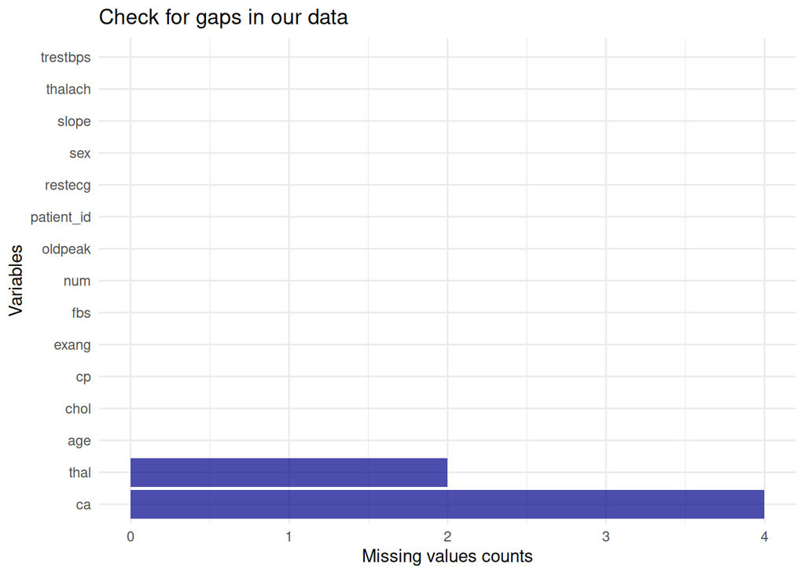

```r
# 1. Check the dataset for gaps in the data
# Create a data frame for the missing values for plotting
df_missing <- data.frame(Variable = names(missing_counts), Missing_Count = missing_counts)
# Load ggplot2
library(ggplot2)

# Plot
ggplot(df_missing, aes(x = reorder(Variable,-Missing_Count), y = Missing_Count)) +
  geom_bar(stat = "identity", fill = "darkblue", alpha = 0.7)+
  coord_flip() + # We flip the graph for improved readability
  labs(title = "Check for gaps in our data",
       x = "Variables",
       y = "Missing values counts") +
  theme_minimal()
```

We do have some missing values, but we removed them in the cleaning steps above.

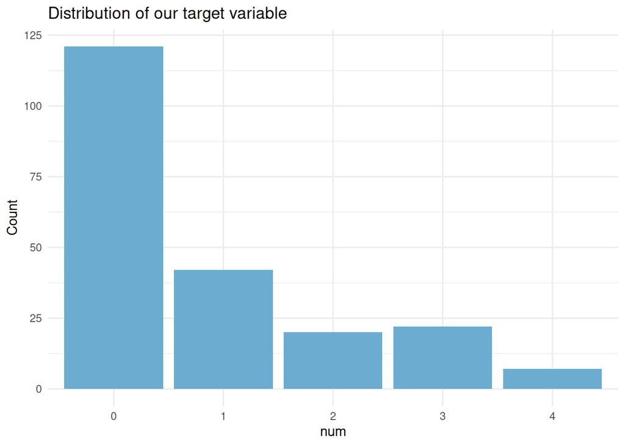

```r
# 2. Look at the distribution of the target variable: heart disease
num_counts <- as.data.frame(table(data_frame$num))

# Plot
ggplot(num_counts, mapping = aes(x=Var1, y=Freq)) +
  geom_bar(stat = "Identity", fill = "#6BACD0") +
  labs(title = "Distribution of our target variable",
       x = "num",
       y = "Count") +
  theme_minimal()
```

The sample seems to be unbalanced, with the majority of the patients being in the category 0 .

```r
# 3: Indicate the types of variables (see paragraph above)
# 4: Look at unique values in the categorical objects
unique(data_frame$sex)
```

```
## [1] 1 0
```

```r
unique(data_frame$cp)
```

```
## [1] 4 3 2
```

```r
unique(data_frame$fbs)
```

```
## [1] 0
```

```r
unique(data_frame$restecg)
```

```
## [1] 2 0 1
```

```r
unique(data_frame$exang)
```

```
## [1] 1 0
```

```r
unique(data_frame$slope)
```

```
## [1] 2 3 1
```

```r
unique(data_frame$thal)
```

```
## [1] 7 3 6
```

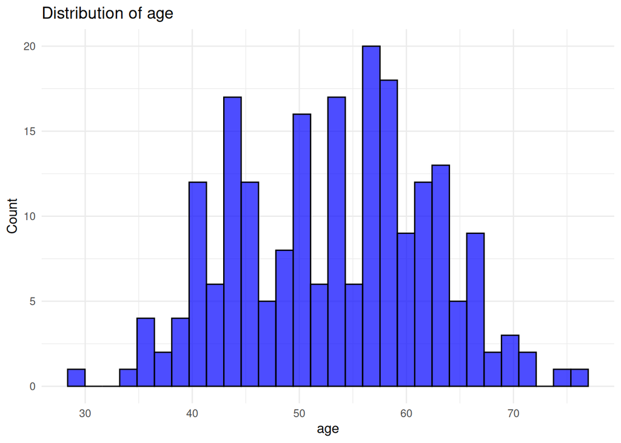

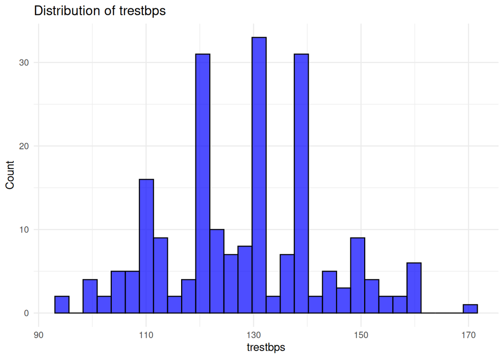

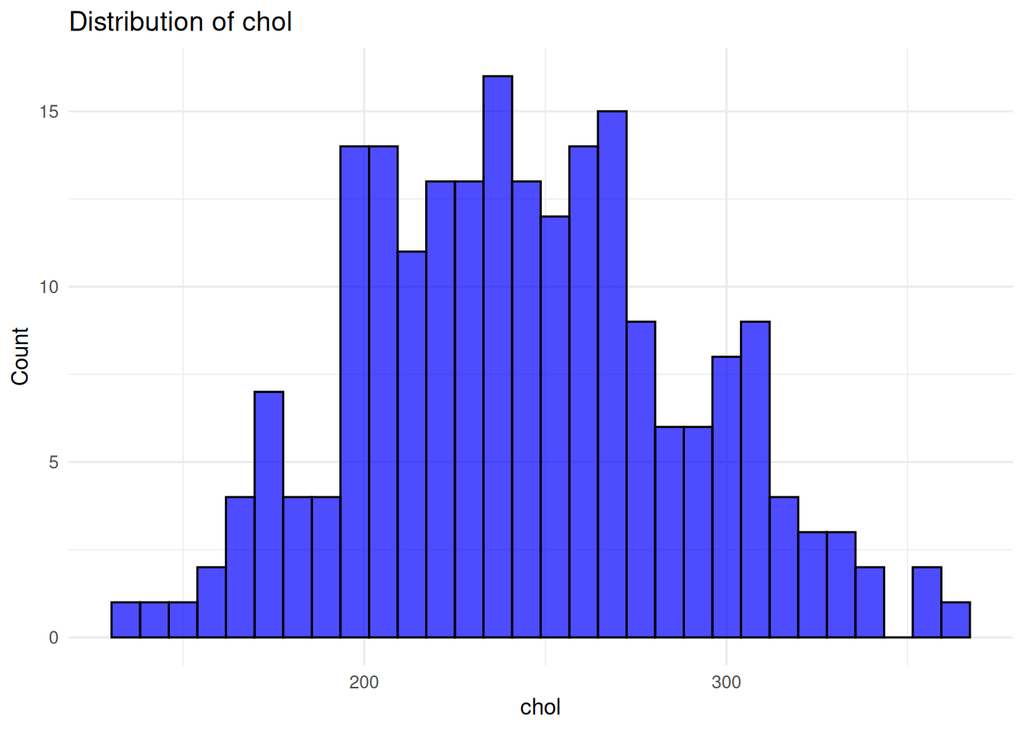

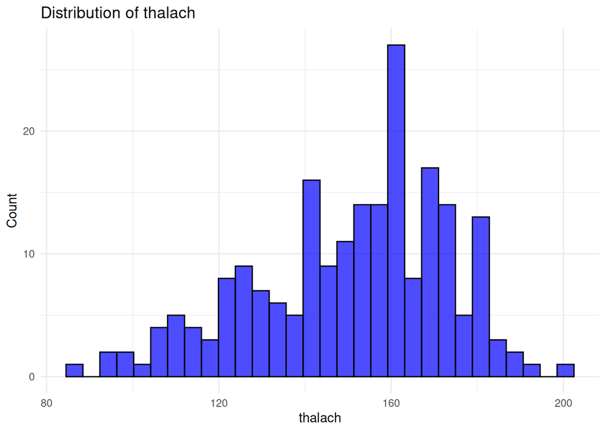

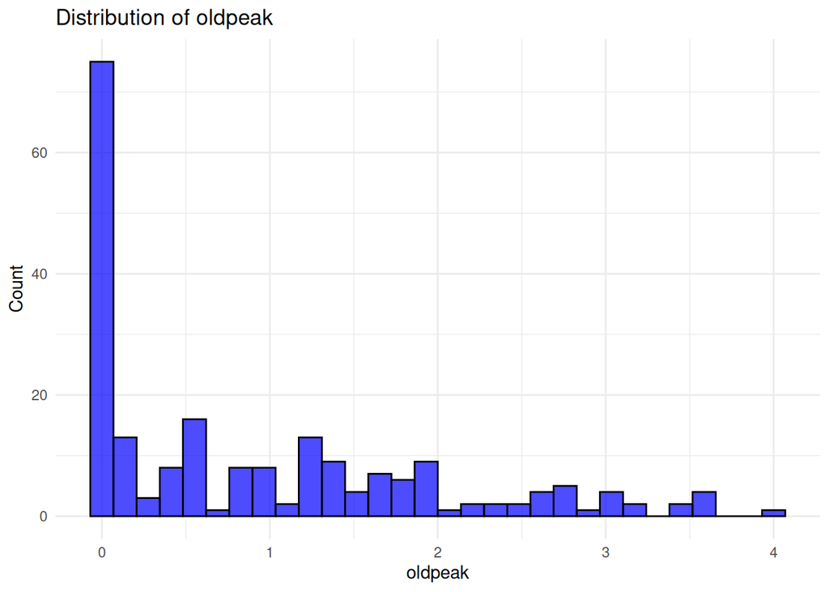

```r
# 5: Analyze numerical variables (visualizing continuous columns)
num_vars <- c("age", "trestbps", "chol", "thalach", "oldpeak")
cat_vars <- c("sex", "cp", "fbs", "restecg", "exang", "slope", "thal", "ca")

for (var in num_vars) {
  print(
    ggplot(data_frame, aes_string(x = var)) +
      geom_histogram(fill = "blue", color = "black", alpha = 0.7, bins = 30) +  # Auto-adjust bins
      labs(title = paste("Distribution of", var), x = var, y = "Count") +
      theme_minimal()
  )
}
```

The distributions of age, cholesterol, and maximum heart rate appear roughly normal, while resting blood pressure shows multiple peaks, suggesting possibly different subgroups within the dataset. ST depression is highly right-skewed, with most values close to zero, indicating that significant ST depression is relatively rare in the dataset.

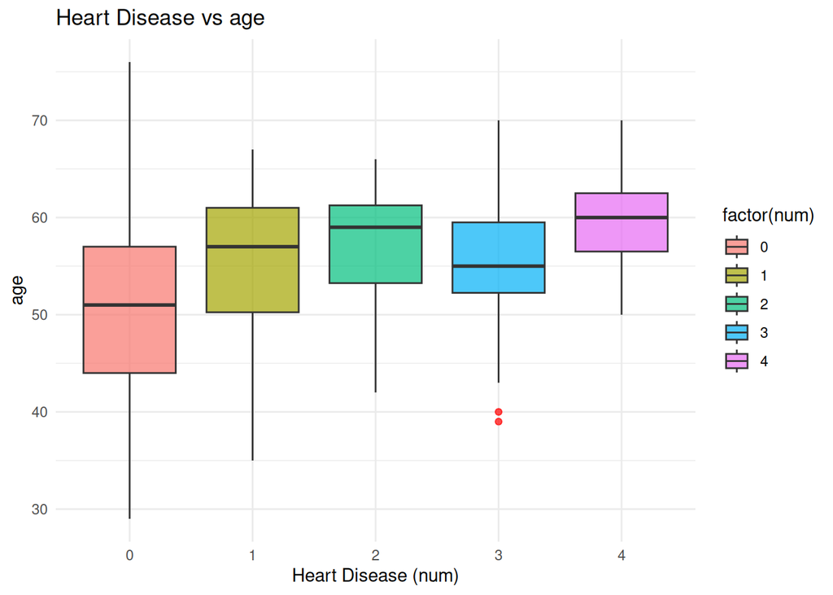

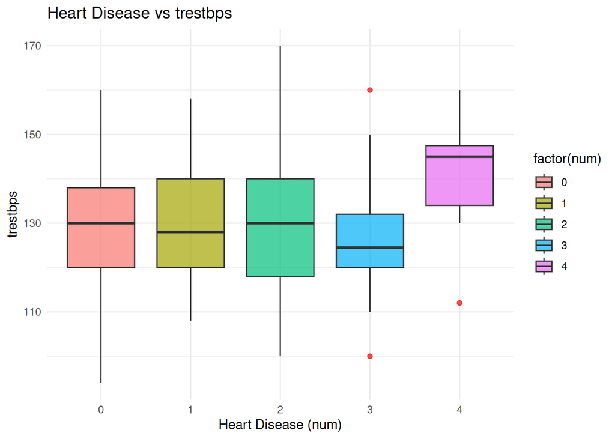

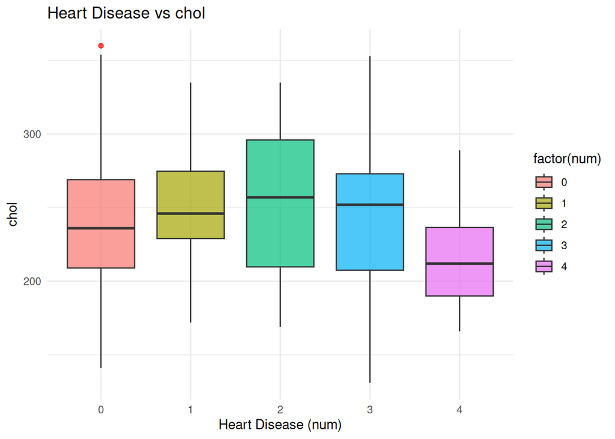

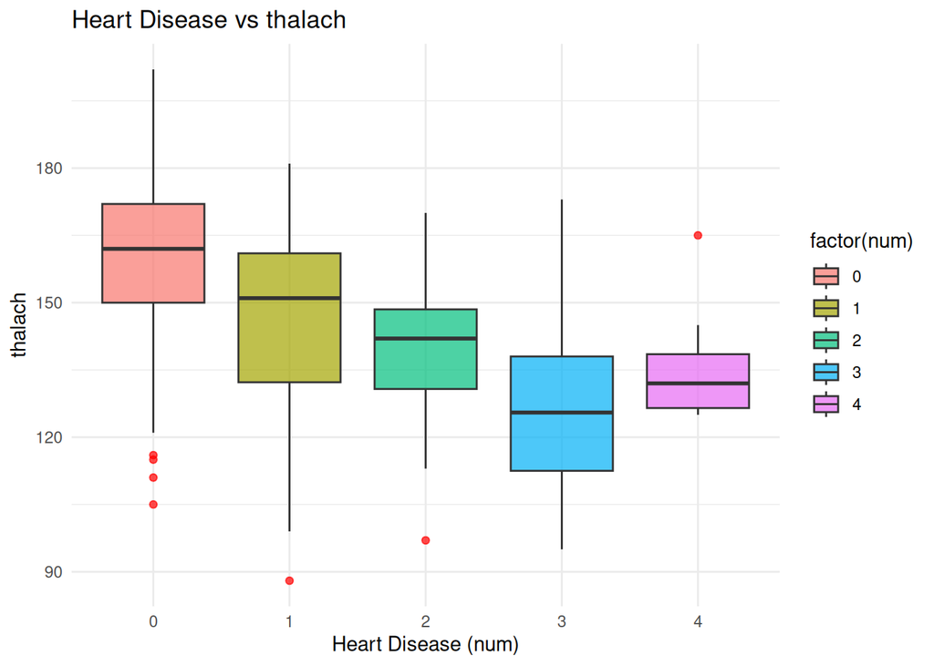

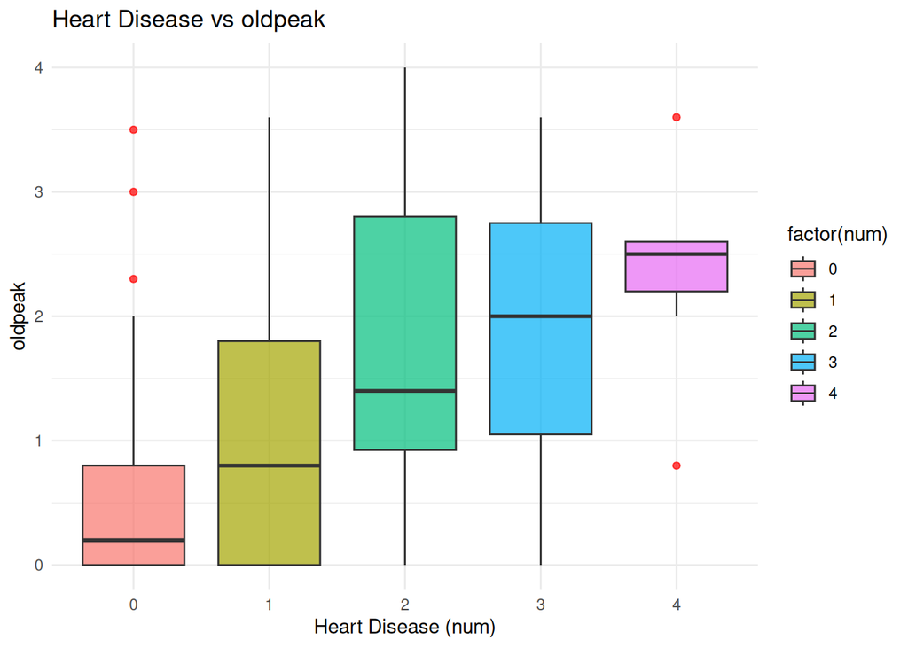

```r
# 6. Look at the distribution of number of people with heart disease from various factors
# Get the number of unique values in num
num_levels <- length(unique(data_frame$num))

# Generate a color palette with enough colors
color_palette <- scales::hue_pal()(num_levels)

for (var in num_vars) {
  print(
    ggplot(data_frame, aes_string(x = "factor(num)", y = var, fill = "factor(num)")) +
      geom_boxplot(alpha = 0.7, outlier.color = "red") +
      scale_fill_manual(values = color_palette) +  # Use dynamic colors
      labs(title = paste("Heart Disease vs", var), x = "Heart Disease (num)", y = var) +
      theme_minimal()
  )
}
```

Thalach decreases, while oldpeak increases with heart disease severity, suggesting their strong predictive value. Age shows a slight upward trend, while trestbps and chol display high variability but no clear pattern.

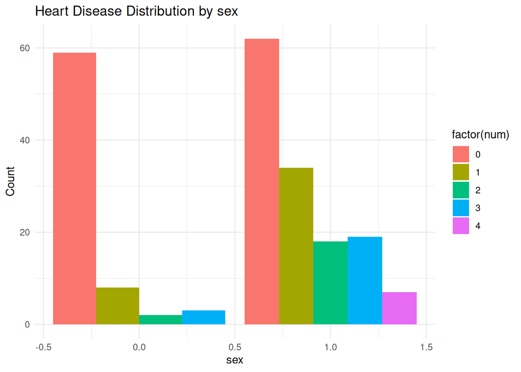

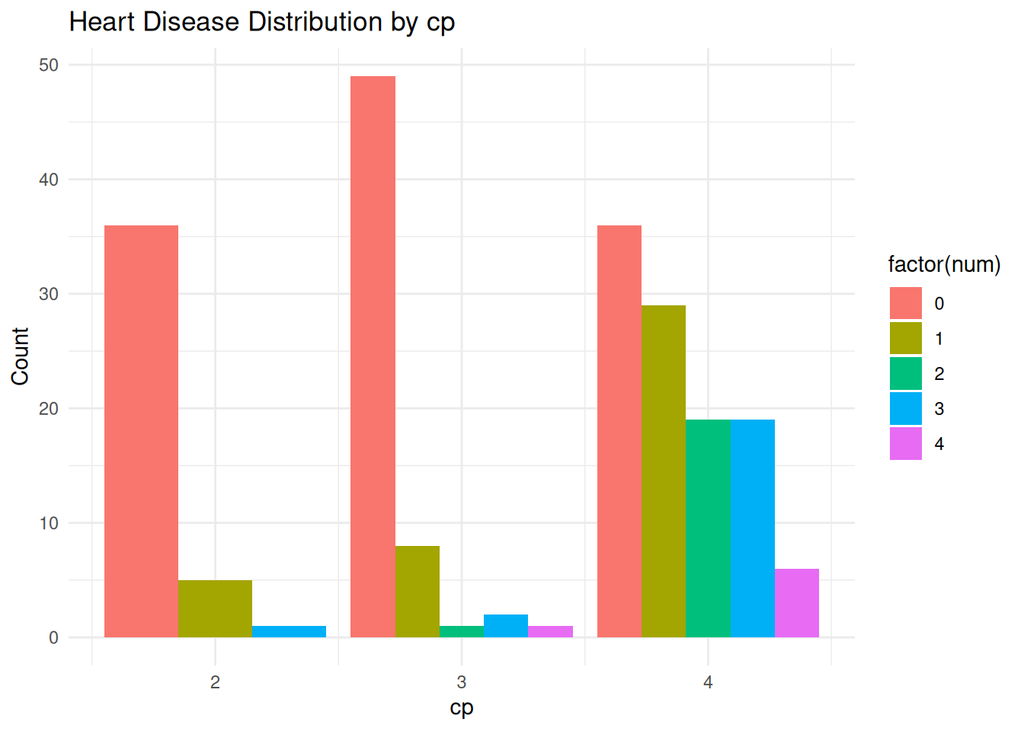

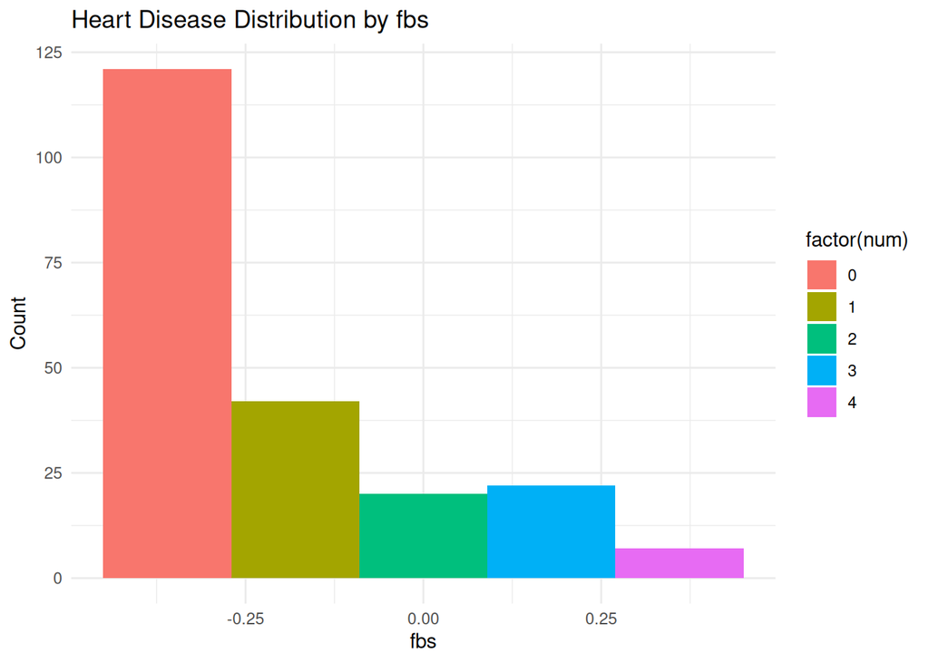

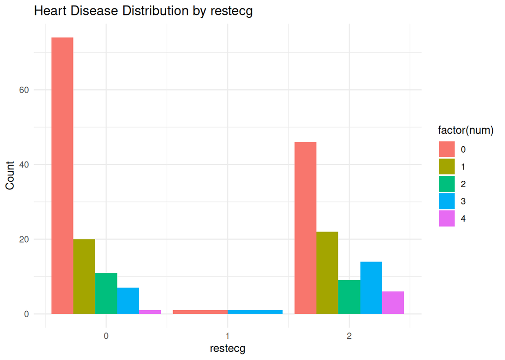

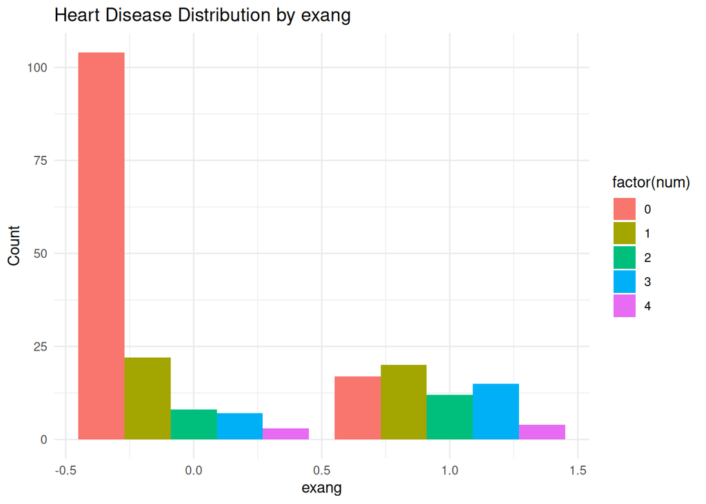

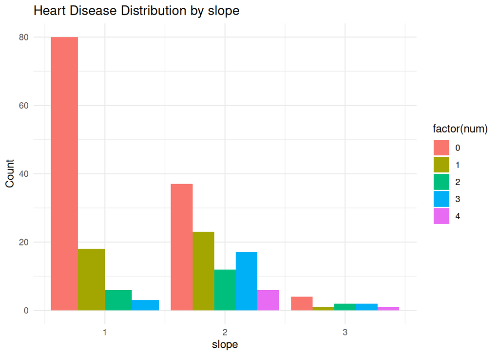

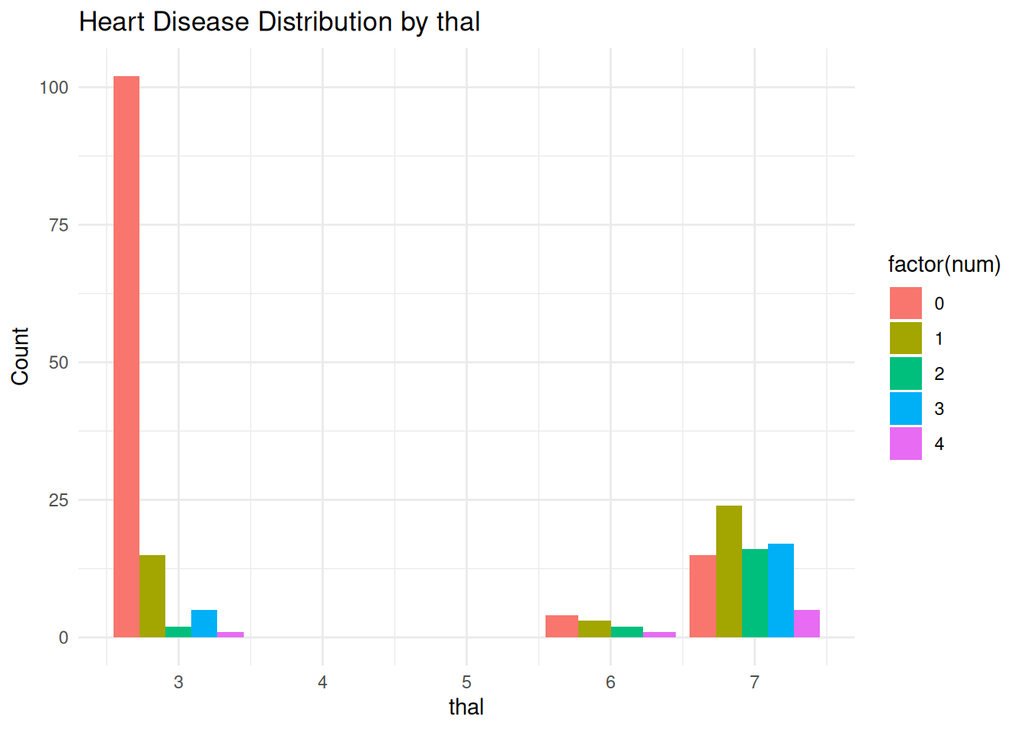

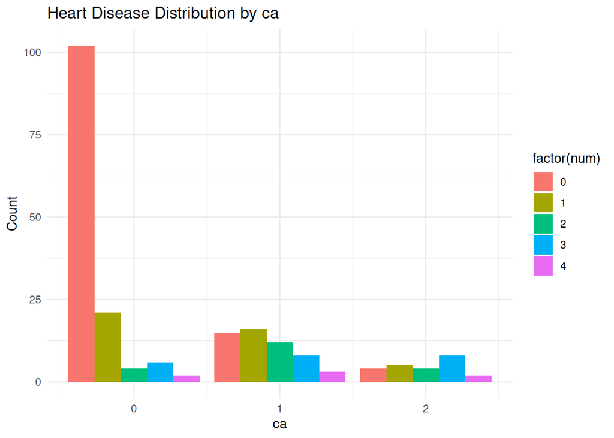

```r
for (var in cat_vars) {
  print(
    ggplot(data_frame, aes_string(x = var, fill = "factor(num)")) +
      geom_bar(position = position_dodge(width = 0.9)) +  # Improved positioning
      labs(title = paste("Heart Disease Distribution by", var), x = var, y = "Count") +
      theme_minimal()
  )
}
```

Heart disease is more prevalent in males, higher chest pain types, and abnormal thalassemia. Higher major vessels count (ca), slope, and exercise-induced angina (exang) also show trends linked to severity.

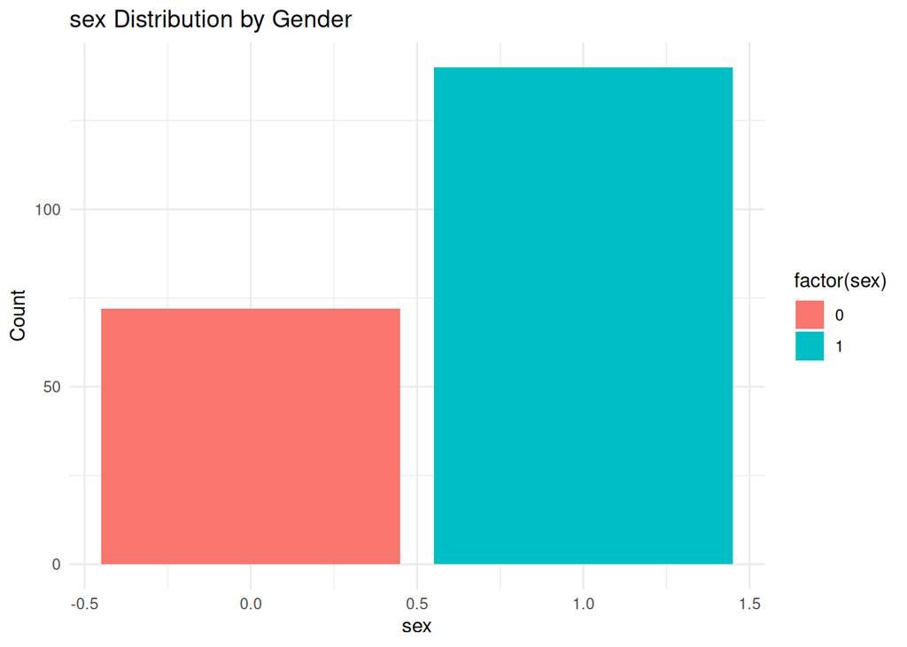

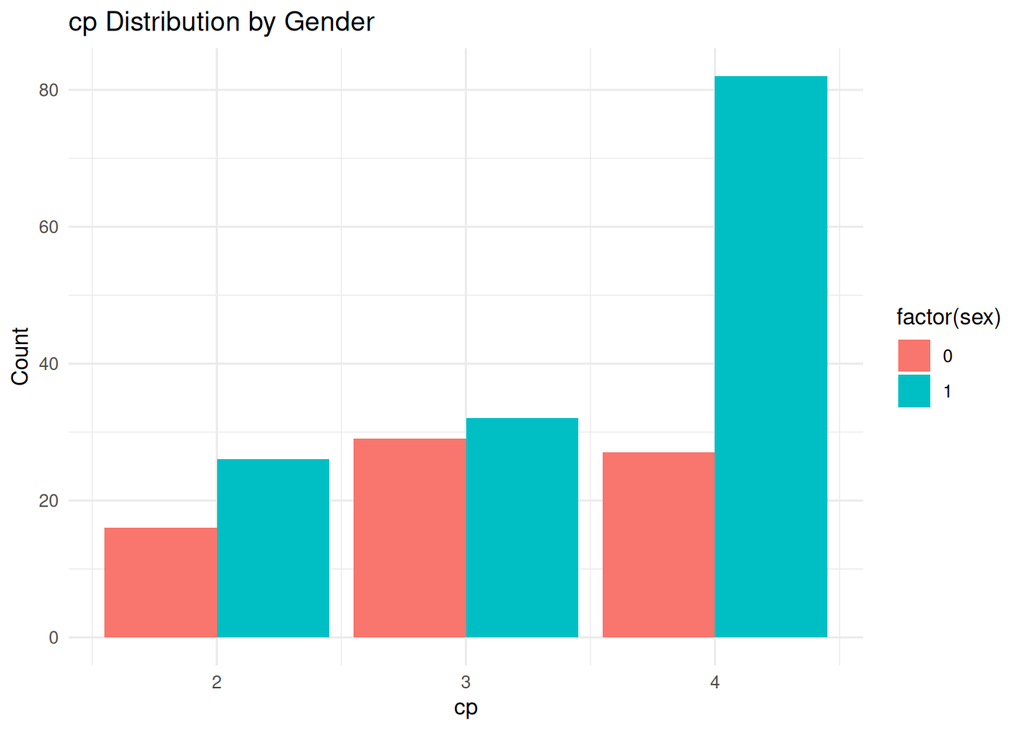

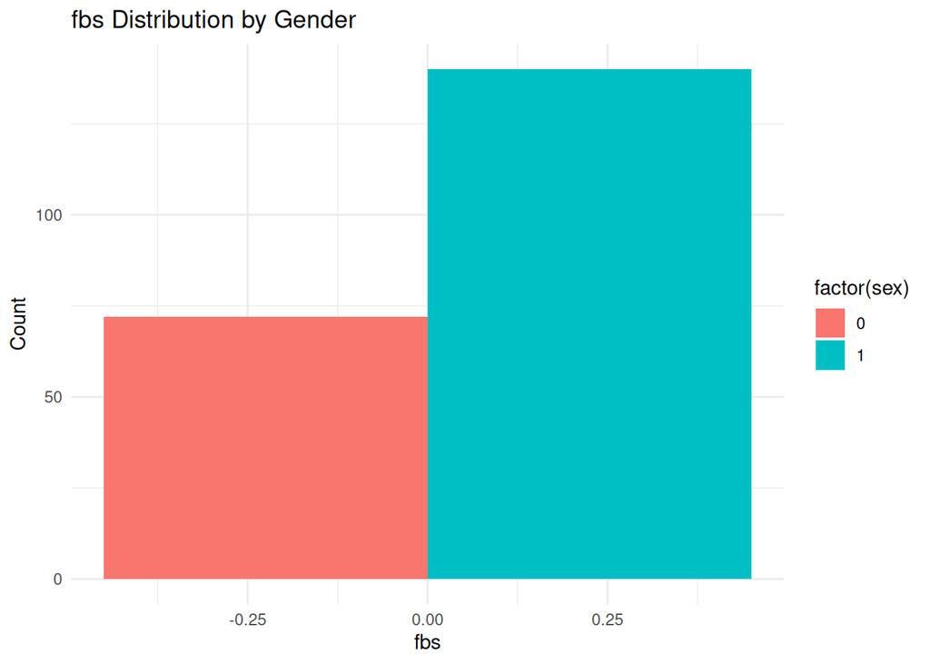

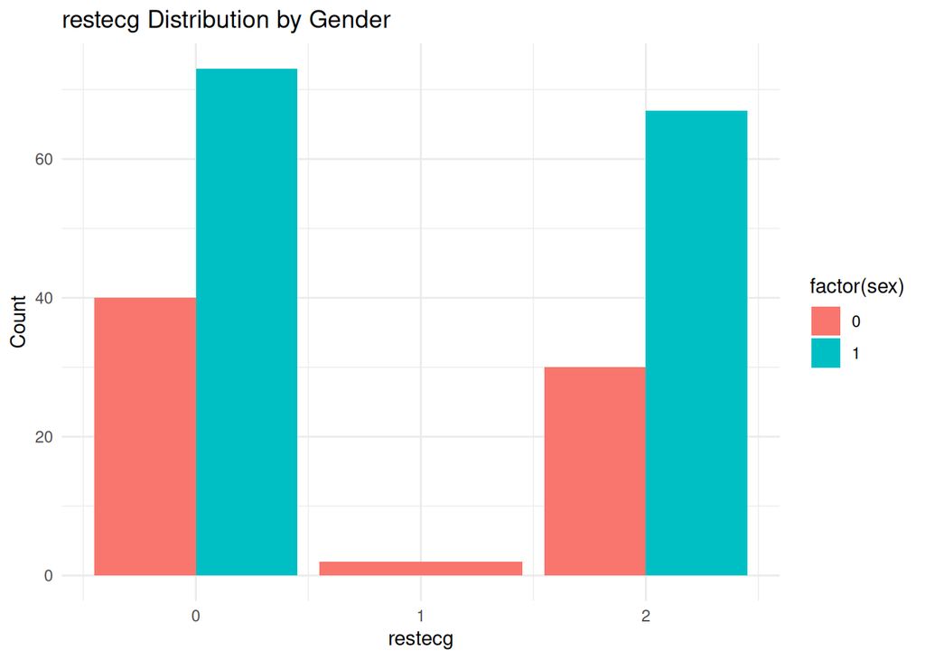

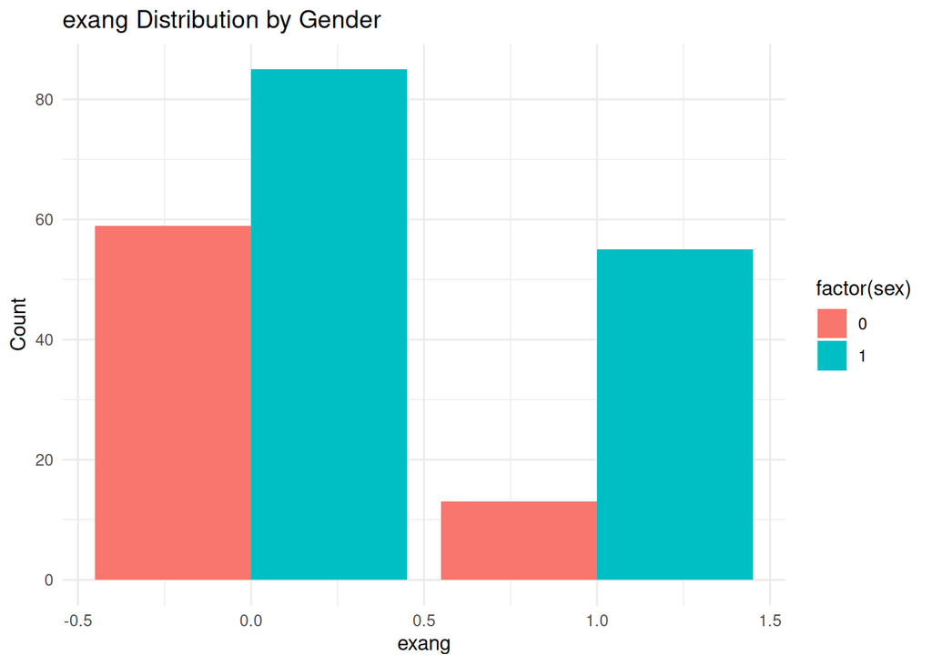

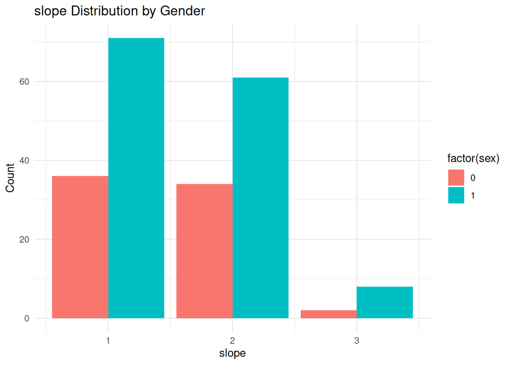

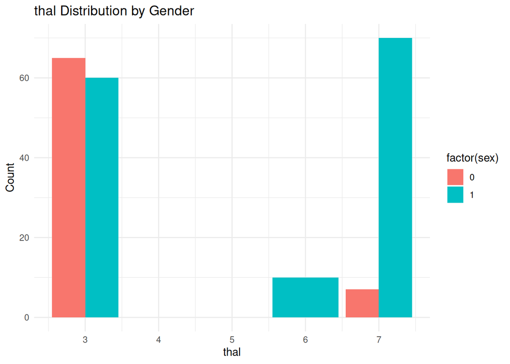

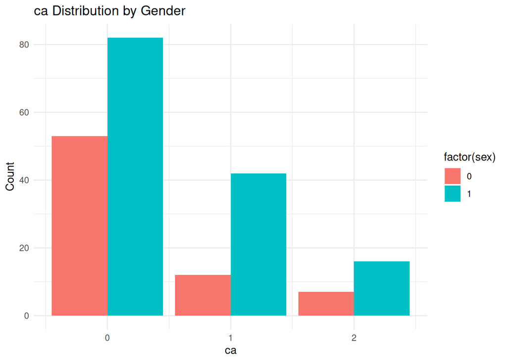

```r
# 7. Look at the distribution of categorical variables depending on gender
for (var in cat_vars) {
  print(
    ggplot(data_frame, aes_string(x = var, fill = "factor(sex)")) +
      geom_bar(position = position_dodge(width = 0.9)) +
      labs(title = paste(var, "Distribution by Gender"), x = var, y = "Count") +
      theme_minimal()
  )
}
```